# Analysis of Women Primary School Completion Rate

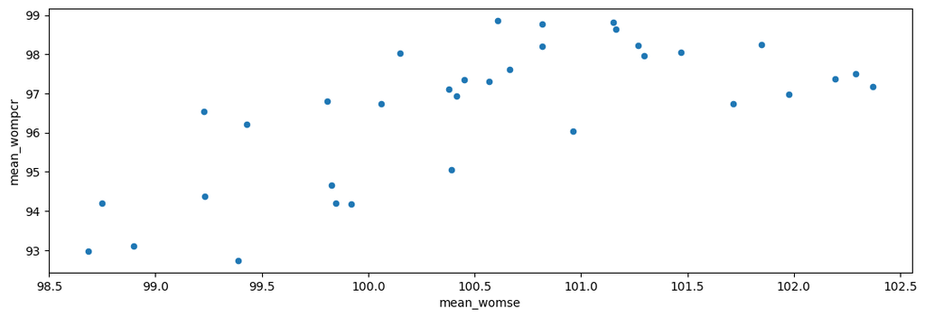

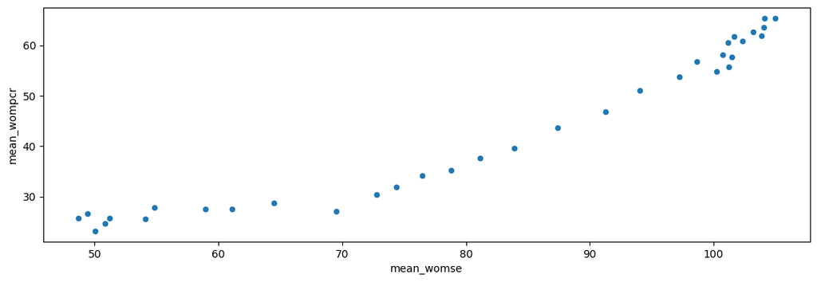

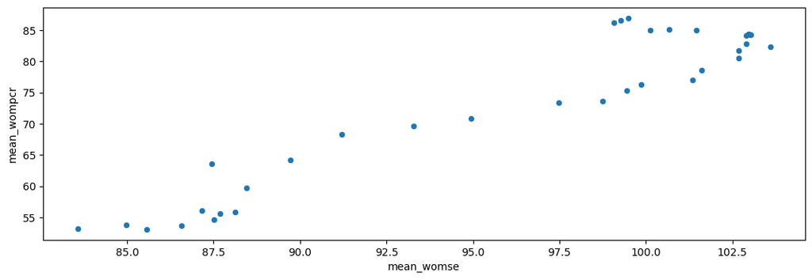

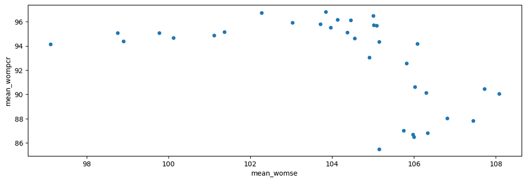

```python
plot_df.rename(columns={"School enrollment, primary, female (% gross)": "mean_womse",\
                        "Primary completion rate, female (% of relevant age group)": "mean_wompcr"}, inplace = True)
plot_df.groupby('IncomeGroup').plot.scatter(x='mean_womse',y='mean_wompcr',figsize=(13,4))
plt.show()
```

```python
# Check if there is linear relationship in those values between total and female primary completion rate.
plot_df_group = plot_df.groupby('IncomeGroup')
for k, g in plot_df_group:
    model = ols('mean_womse ~ mean_wompcr', g)
    results = model.fit()
    print(results.summary())
```

```
                            OLS Regression Results
==============================================================================
Dep. Variable:             mean_womse   R-squared:                       0.483
Model:                            OLS   Adj. R-squared:                  0.467
Method:                 Least Squares   F-statistic:                     29.89
Date:                Sun, 15 Dec 2024   Prob (F-statistic):           5.11e-06
Time:                        03:02:27   Log-Likelihood:                -37.567
No. Observations:                  34   AIC:                             79.13
Df Residuals:                      32   BIC:                             82.19
Df Model:                           1
Covariance Type:            nonrobust
===============================================================================
                  coef    std err          t      P>|t|      [0.025      0.975]
-------------------------------------------------------------------------------
Intercept      62.0061      7.048      8.798      0.000      47.650      76.362
mean_wompcr     0.3989      0.073      5.467      0.000       0.250       0.548
==============================================================================
Omnibus:                        2.208   Durbin-Watson:                   0.373
Prob(Omnibus):                  0.331   Jarque-Bera (JB):                2.021
Skew:                           0.552   Prob(JB):                        0.364
Kurtosis:                       2.545   Cond. No.                     5.27e+03
==============================================================================

Notes:
[1] Standard Errors assume that the covariance matrix of the errors is correctly specified.
[2] The condition number is large, 5.27e+03. This might indicate that there are
strong multicollinearity or other numerical problems.
                            OLS Regression Results
==============================================================================
Dep. Variable:             mean_womse   R-squared:                       0.926
Model:                            OLS   Adj. R-squared:                  0.924
Method:                 Least Squares   F-statistic:                     402.6
Date:                Sun, 15 Dec 2024   Prob (F-statistic):           1.08e-19
Time:                        03:02:27   Log-Likelihood:                -106.30
No. Observations:                  34   AIC:                             216.6
Df Residuals:                      32   BIC:                             219.6
Df Model:                           1
Covariance Type:            nonrobust
===============================================================================
                  coef    std err          t      P>|t|      [0.025      0.975]
```

[output cut: 49 more lines]

```
                  coef    std err          t      P>|t|      [0.025      0.975]
-------------------------------------------------------------------------------
Intercept     141.5340     10.574     13.386      0.000     119.996     163.072
mean_wompcr    -0.4028      0.114     -3.541      0.001      -0.635      -0.171
==============================================================================
Omnibus:                        8.703   Durbin-Watson:                   0.256
Prob(Omnibus):                  0.013   Jarque-Bera (JB):                7.679
Skew:                          -1.133   Prob(JB):                       0.0215
Kurtosis:                       3.536   Cond. No.                     2.45e+03
==============================================================================

Notes:
[1] Standard Errors assume that the covariance matrix of the errors is correctly specified.
[2] The condition number is large, 2.45e+03. This might indicate that there are
strong multicollinearity or other numerical problems.
```

As the above scatter plots and OLS result summaries indicate, the linear model can only predict the pattern between female primary school enrollment and female primary school completion rate within groups "Low Income" and "Lower Middle Income", so it's not very correlated with female primary school completion rate.

# Machine Learning

As GDP per capita and the total primary completion rate predict the most when the countries are divided by their income groups, when building the model, I consider to divide all the countries by income groups instead of region and include GDP per capita and the total primary completion rate as features. This time I still choose to predict the future data using linear model, since using the machine learning regressors sometimes gives me skyrocketing results such as 600%, which is unrealistic. To avoid this, I prefer linear regression.  
Among all the features, GDP per capita and total primary school completion rate can be taken to build a linear model to predict the future female primary school completion rate. Therefore, I treat them as features, and female primary school completion rate as the target.

```python
# select wanted columns
model_df = df.loc[df['IncomeGroup'] != '-'].groupby(["IncomeGroup","yearID"])\
                                                [['GDP per capita, PPP (current international $)',\
                                                  'Primary completion rate, total (% of relevant age group)',\
                                                  'Primary completion rate, female (% of relevant age group)']].aggregate("mean")

# features
X = model_df[['GDP per capita, PPP (current international $)','Primary completion rate, total (% of relevant age group)']]
# target
y = model_df['Primary completion rate, female (% of relevant age group)']

# build the regression model
regr = LinearRegression()
# fit the model
regr = regr.fit(X,y)

# print the score
print(regr.score(X,y))
# print the coefficients
print(regr.coef_)
# print the intercept, i.e., bias
print(regr.intercept_)
```

```
0.9965293515514871
[-1.81875179e-05  1.10397424e+00]
-9.447017115978099
```

The output above means that our ideal model for this case is $$\text{womed} = -1.81875179\times 10^{-5}\times \text{gdppc}+1.10397424\times \text{totpcr}-9.447017115978099$$

# Insight and Policy Decision

It's obvious that the coefficients have huge different in magnification. Generally, we can consider standardizing GDP per capita (gdppc) and total primary completion rate (totpcr) such that the coefficients are similar to each other. However, in a practical sense, the former feature is usually $10^5$ times the latter feature, so I decide not to standardize the features and make this regression equation ready to use for any paired GDP per capita and total primary completion rate.
In other words, the final model to predict female primary school completion rate is $$\text{womed} = -1.81875179\times 10^{-5}\times \text{gdppc}+1.10397424\times \text{totpcr}-9.447017115978099$$ Plug any paired GDP per capita and total primary completion rate gives us the prediction with R^2 score of $0.9965293515514871$.

# Other Resources

1. J.P. Morgan Research post of economy recession probability

https://www.jpmorgan.com/insights/global-research/economy/recession-probability#:~:text=Global%20recession%20outlook,by%20the%20end%20of%202025.  
2. The source of data and definitions of indicators  
https://databank.worldbank.org/metadataglossary/jobs/series/SE.PRM.CMPT.FE.ZS  
3. More about the importance of female primary education (MCC webpage)  
https://www.mcc.gov/who-we-select/indicator/girls-primary-education-completion-rate-indicator/#:~:text=This%20is%20measured%20as%20the,the%20last%20grade%20of%20primary.  
4. Short introduction and quick start on Numpy and Pandas:  
https://www.codecademy.com/article/introduction-to-numpy-and-pandas  
5. Wikipedia introduction to csv files:  
https://en.wikipedia.org/wiki/Comma-separated_values#:~:text=Comma%2Dseparated%20values%20(CSV),typically%20represents%20one%20data%20record.  
6. Webpage of the raw data, where you can download the data files of many format including csv and excel. You can also find and download similar datasets.  
https://data.worldbank.org/indicator/SE.PRM.CMPT.FE.ZS?locations=1W&start=1973&view=chart  
7. More information on the module LinearRegression:  
https://scikit-learn.org/1.5/modules/generated/sklearn.linear_model.LinearRegression.html